# penguin assignment

Candidate 1054581

2022-12-08

### Question 1

#### The reproducibility crisis in science and why we should care

The reproducibility crisis is typified by the fact that research across many scientific fields is not actually reproducible by both others and by the researchers who published the work. An article by Monya Baker in nature put together the implications of a short survey of natures researchers. It showed that 70% agreed there was a crisis with 52% believing the crisis was significant. However, when looking at what fields are suffering from a lack of reproducibility, it suggested that biology was among the fields with some of the lowest reproducibility. It is viewed as a crisis due to the fact that confidence in published research is being diminished and as such, It is becoming more difficult to add to the work done by others. These are compounded with a lack of open access and good practices within the methodological process.

There are many reasons for biology to care about this crisis. Having confidence in the research we found our hypotheses upon is very important as making conclusions based on results is already difficult enough. The crisis has also revealed other hurdles in the field such as poor mentor-ship, selective reporting, bad internal replication and unavailability of methods. Open science is something that is worth moving towards, and to do so, we must address the lack of reproducibility that is present within the field. The benefits of this shift are outlined within Mckiernan et al’s paper in eLife and present a few compelling reasons. While citation number doesn’t seem to be increased as much for biological sciences when research is open, applied fields greatly benefit from the openness of their research and methodology. Furthermore, open methodologies with clear version control and tracing of changes can better help researchers to constructively critique the work and also increase the opportunity for cooperation. This would lead to a greater number of discoveries and help to reduce the number of dead ends resulting from malpractice or mistakes.

The paper also made cases against the fears of open science. Fear against poor peer review and prestige has been revealed to be mostly unfounded, with some open access services actually having equivalent reputation as those with close access services. In terms of peer review, the open nature of the review process has led some services to have a more stringent and constructive system than those of bigger, closed journals. This builds on the benefits of moving to an open system as it allows the researches to better understand the process behind review and get recorded feedback on the research they publish. By being more reproducible, we are therefore required to be more open as the main hindrance to reproducing research is components of that research being hidden or missing. If we remove this barrier, our research appears to suffer no cost.

Fundamentally, better reproducibility requires and increased effort from researchers collectively and individually. Once implemented, the practice should become easy and habitual and would lead to a better environment that is more conducive and scientific.

### Question 2

#### A poorly represented figure

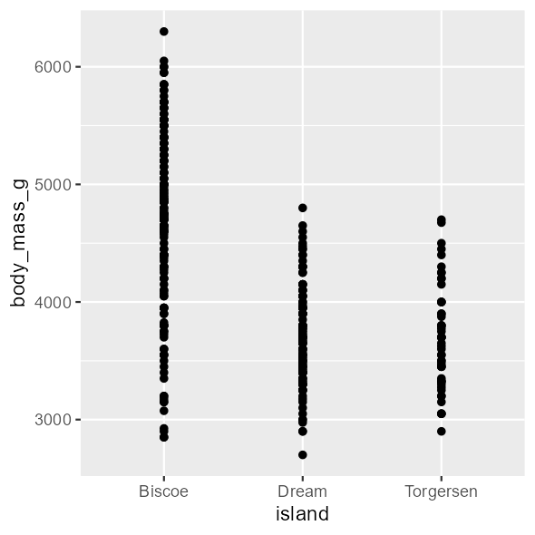

The figure breaks quite a few of the general rules of good visual presentation. Firstly, the use of geom_point isn’t the most suitable for this kind of data representation as the independent variable is categorical. A boxplot or bar column would have been better suited to represent and understand what the data implies. Furthermore, the plot is visually unappealing. It has the default theme colouring with no additional colours. It makes it difficult to interpret anything and garner any form of focus or interest. On top of this, using colour and a legend would have shown differences within the groups of interest and not just penguins arbitrarily. The points themselves are incredibly difficult to tell apart as they all intersect one another, again showing that geom_point was not very suitable. The png itself is flawed in the way that it was coded. It was coded with a poor resolution, bad scaling and large size. This means its not actually able to be applied to other forms of media such as a presentation or a poster. An SVG would be far more suitable due to its infinite scalability. Finally, the graph could have been split by penguins for better effect.

### Question 3

#### The importance of colour choice and what considerations should be made

The choice of colour used within a scientific figure plays an important role not only in the interpretation of the reader but of the researcher making the figure too. The palette that we use can have major effects on the way data is represented and so it is very important that we consider the kind of colour maps we choose to fit to our data. A paper by Crameria et al in nature expresses the importance of this, the theory behind it and the ways in which we can implement it into future research.

Firstly, colour maps can distort our representation of data. If we use rainbow as an example, it can make it difficult to pick out the original image if we apply a rainbow colour map to the image. This means that it is likely having the same effect on the figures that it is applied to. We can consider maps like these to be unscientific. They are dangerous because they result in a blind interpretation of the data due to the distortion caused by the map. If we don’t know what the “original image” of the data is, then we may assume the one produced with the map is the original image which therefore can misconstrue the implications.

Furthermore, colourmaps can discriminate against people. Poor maps like rainbow are not accessible to people with colour vision deficiencies and therefore blocks out a reasonable fraction of people from accessing a paper and its interpretations.

Therefore, we must consider the properties of any colourmap that we choose to use. The map must be uniform, without error and have a proportionally linear lightness and brightness. If the map is uniform, we can make use of it like we would a numerical axis with the use of a colour bar. Along with this, ensuing lightness and brightness of the map is both proportional to on another and linear will stop the formation of artificial gradients within the data. This allows for perceptual order to be achieve making the data’s representation inherently understandable. It is also wise to consider that inclusion of a colour bar with a gradient is a necessity and not a nicety. Without the bar, it makes it unreasonably difficult to understand what the gradient is supposed to represent and is equivalent to removing the ticks from a numerical axis.

Finally, the type of colour scale we use is of importance when we consider the nature of the data itself. There are different classes of colour maps such as converging/diverging, circular, multisequential and sequential. Using the correct class for the correct data type is a necessity. Editing the map is also unwise as it will edit the linearity of the map.

### Question 4

#### Statistically analysing the penguins dataset and producing a figure.

The source code, data, functions and outputs are all found within this repository.

https://github.com/AssignmentAccount/Penguins

### Question 5

#### Reviewing someone elses work